# OVERVIEW

1. Using Polynomial Regression for **Non-Linear Regression** problem.
2. The data from the file `PolynomialRegressionData_I.csv` was plotted using matplotlib.
3. A PolynomialFeatures transformation was performed, then linear regression was performed to calculate the optimal ordinary least squares regression model parameters.
4. The first figure was recreated by adding the best fit curve to all subplots.
5. The true model parameters were inferred.

# PRELIMINARIES

```python
#===============
# COMMON IMPORTS
#===============
from mpl_toolkits.mplot3d import Axes3D
import matplotlib.pyplot as plt
import matplotlib as mpl
from mpl_toolkits import mplot3d
from matplotlib import cm
from sklearn.preprocessing import PolynomialFeatures
from sklearn.linear_model import LinearRegression
import numpy as np
import pandas as pd
import os
%matplotlib inline
mpl.rc('axes', labelsize=14)
mpl.rc('xtick', labelsize=12)
mpl.rc('ytick', labelsize=12)

#=================================
# WHERE TO SAVE THE FIGURES METHOD
#=================================
PROJECT_ROOT_DIR = "."
FOLDER = "figures"
IMAGES_PATH = os.path.join(PROJECT_ROOT_DIR, FOLDER)
os.makedirs(IMAGES_PATH, exist_ok=True)
def save_fig(fig_id, tight_layout=True, fig_extension="png", resolution=300):
    path = os.path.join(IMAGES_PATH, fig_id + "." + fig_extension)
    print("Saving figure", fig_id)
    if tight_layout:
        plt.tight_layout()
    plt.savefig(path, format=fig_extension, dpi=resolution)
```

# IMPORTING NON LINEAR DATA

```python
fileName = "PolynomialRegressionData_I.csv"

PolynomialRegressionData_I = pd.read_csv(fileName)
```

# CREATING FIRST IMAGE OF NON LINEAR DATA

**RAW 3D SCATTERPLOTS OF THE 'PolynomialRegressionData_I' DATA IN EACH OF THE 4 SUBPLOTS.**

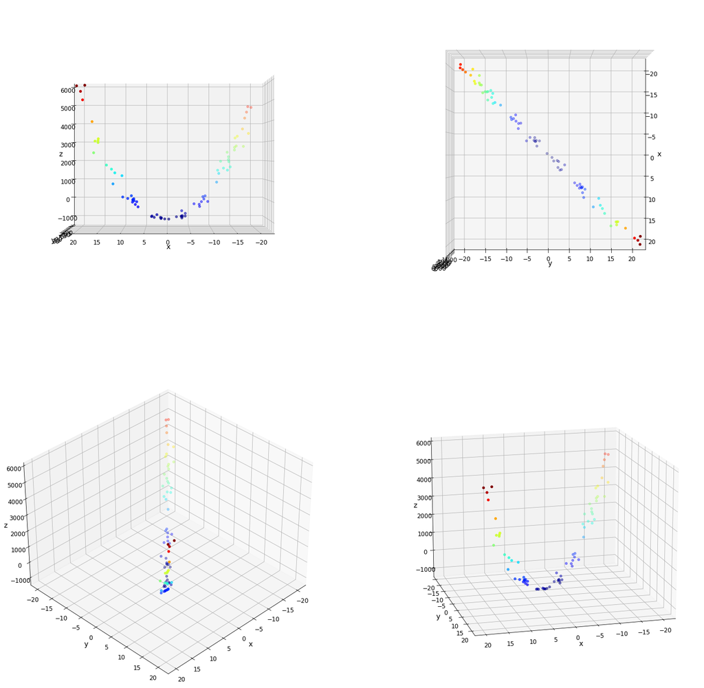

```python
#============================================================================
# GET SEPARATE 'x', 'y', AND 'z' DATA FROM PolynomialRegressionData_I DATASET
#============================================================================
xdata = PolynomialRegressionData_I["x"]
ydata = PolynomialRegressionData_I["y"]
zdata = PolynomialRegressionData_I["z"]

# SIZE OF FIGURE
fig = plt.figure(figsize = [25, 25])


#============================
# FIRST SUBPLOT - SCATTERPLOT
#============================
#IN THE 2 ROWS AND 2 COLUMNS PLOT HERE, THERE'S 1st SUBPLOT
ax1 = fig.add_subplot(2, 2, 1, projection = '3d')
#CHANGE DEFAULT VIEW ANGLE USING view_init() METHOD.
#ELEVATION: 0 DEGREES ABOVE x - y PLANE
#ROTATION: 90 DEGREES COUNTER CLOCKWISE ABOUT z-AXIS
ax1.view_init(0, 90)
#COLOR OF CMAP TO ZDATA
ax1.scatter3D(xdata, ydata, zdata, c=zdata, cmap='jet');

#=============================
# SECOND SUBPLOT - SCATTERPLOT
#=============================
#SET UP THE AXES FOR THE FIRST PLOT
ax2 = fig.add_subplot(2, 2, 2, projection = '3d')   #IN THE 2 ROWS AND 2 COLUMNS PLOT HERE, THERE'S 2nd SUBPLOT
#CHANGE DEFAULT VIEW ANGLE USING view_init() METHOD.
#ELEVATION: 90 DEGREES ABOVE x - y PLANE
#ROTATION: 0 DEGREES COUNTER CLOCKWISE ABOUT z-AXIS
ax2.view_init(90,0)
#COLOR OF CMAP TO ZDATA
ax2.scatter3D(xdata, ydata, zdata, c=zdata, cmap='jet');

#============================
# THIRD SUBPLOT - SCATTERPLOT
#============================
#IN THE 2 ROWS AND 2 COLUMNS PLOT HERE, THERE'S 3rd SUBPLOT
ax3 = fig.add_subplot(2, 2, 3, projection = '3d')
#CHANGE DEFAULT VIEW ANGLE USING view_init() METHOD.
#ELEVATION: 35 DEGREES ABOVE x - y PLANE
#ROTATION: 45 DEGREES COUNTER CLOCKWISE ABOUT z-AXIS
ax3.view_init(35, 45)
#COLOR OF CMAP TO ZDATA
ax3.scatter3D(xdata, ydata, zdata, c=zdata, cmap='jet');

#=============================
# FOURTH SUBPLOT - SCATTERPLOT
#=============================
#IN THE 2 ROWS AND 2 COLUMNS PLOT HERE, THERE'S 4th SUBPLOT
ax4 = fig.add_subplot(2, 2, 4, projection = '3d')
#CHANGE DEFAULT VIEW ANGLE USING view_init() METHOD.
#ELEVATION: 15 DEGREES ABOVE x - y PLANE
#ROTATION: 75 DEGREES COUNTER CLOCKWISE ABOUT z-AXIS
ax4.view_init(15,75)
#COLOR OF CMAP TO ZDATA
ax4.scatter3D(xdata, ydata, zdata, c=zdata, cmap='jet');


#================
# SET AXIS LABELS
#================
ax1.set_xlabel('x')
ax1.set_ylabel('y')
ax1.set_zlabel('z')

ax2.set_xlabel('x')
ax2.set_ylabel('y')
ax2.set_zlabel('z')

ax3.set_xlabel('x')
ax3.set_ylabel('y')
ax3.set_zlabel('z')

ax4.set_xlabel('x')
ax4.set_ylabel('y')
ax4.set_zlabel('z')

#==========
# SHOW PLOT
#==========
plt.show()
```

# TRAINING LINEAR REGRESSION MODEL ON NON LINEAR DATA

**ACTUALLY, NON LINEAR FEATURE DATA TRANSFORMED TO POLYNOMIAL FEATURE DATA. THE LINEAR REGRESSION MODEL TRAINS ON TRANSFORMED POLYNOMIAL FEATURE DATA AND NON-TRANSFORMED TARGET DATA.**

### TRANSFORMING NON-LINEAR FEATURE DATA TO POLYNOMIAL FEATURE DATA

```python
#==========================
# FEATURE DATA FROM DATASET
#==========================
#The 'x' and 'y' are the feature data.
#Select data in columns 'x' and 'y' as feature data dropping columns 'z' from dataset
PolynomialRegressionData_I_Features = PolynomialRegressionData_I.drop("z", axis=1)

#========================
# lABEL DATA FROM DATASET
#========================
#The 'z' is the response data.
#The data from 'z' coloumn is return as targets
PolynomialRegressionData_I_Targets = PolynomialRegressionData_I["z"].copy()
```

```python
#==============================
# DATA CLEANING FEATURE DATASET
#==============================

#Finding rows with null values
sample_incomplete_rows = PolynomialRegressionData_I_Features[PolynomialRegressionData_I_Features.isnull().any(axis=1)].head()

#Get median values
x_median = PolynomialRegressionData_I_Features["x"].median()
y_median = PolynomialRegressionData_I_Features["y"].median()

#Fill in null values, if any, with median values
sample_incomplete_rows["x"].fillna(x_median, inplace=True)
sample_incomplete_rows["y"].fillna(y_median, inplace=True)
```

```python
#===============================================================
# TRANSFORM EACH RAW FEATURE TO SECOND DEGREE POLYNOMIAL FEATURE
#===============================================================

#Instantiate object of PolynomialFeatures class:
#Polynomial degree is set to 2. Bias term (intercept) is not included
#in the model itself beause linear regression model will generate that.
poly_features = PolynomialFeatures(degree=2, include_bias=False)

#Fit, train, and transform feature data set to polynomials
X_poly = poly_features.fit_transform(PolynomialRegressionData_I_Features)
```

### TRAINING LINEAR REGRESSION MODEL ON TRANSFORMED POLYNOMIAL FEATURE DATA

**TRAIN ON TRANSFORMED POLYNOMIAL FEATURE DATA AND NON-TRANSFORMED TARGET DATA.**

```python
#================================================================
# TRAIN LINEAR REGRESSION MODEL ON TRANSFORMED POLYNOMIAL FEATURE
#================================================================

#Instantiate object of LinearRegresssion class
model = LinearRegression()

#fit and train model with transformed polynomial features and non-transformed target values
model.fit(X_poly, PolynomialRegressionData_I_Targets)
```

```
LinearRegression()
```

```python
#===========================================================
# OPTIMAL MODEL PARAMETERS: MODEL COEFFICIENTS AND INTERCEPT
#===========================================================
print("Computed Model Coefficients: ", model.coef_)
print("Computed Model Intercept : ", model.intercept_)
```

```
Computed Model Coefficients:  [ 8.09457649 -0.09962593 -0.05144212  0.10558512 15.94863437]
Computed Model Intercept :  -1000.1381149275444
```

# CREATING SECOND IMAGE OF DATA AND PREDICTIVE LINE

**RECREATE RAW 3D SCATTERPLOTS OF THE 'PolynomialRegressionData_I' DATA AND PLOT PREDICTIVE LINE OF BEST FIT**

**USING THE `x_fit` AND `y_fit` DATA TO COMPUTE `z_fit` BY INVOKING THE LINEAR REGRESSION MODEL'S `predict()` METHOD. THIS ALLOWS THE PLOTTING OF THE LINE OF BEST FIT THAT IS PREDICTED BY THE MODEL.**

### GENERATE 'x_fit' AND 'y_fit' FEATURE DATA USING linspace() METHOD

```python
#=================
# DATA FOR 3D LINE
#=================
#Generate x_fit and y_fit feature data using linspace()
x_fit = np.linspace(-21,21,1000)              #'x_fit' numpy array
y_fit = x_fit                                 #'y_fit' numpy array
```

### TRANSFORM FEATURE DATA TO POLYNOMIAL FEATURE DATA

```python
#================================================================================================================
# TRANSFORM x_fit AND y_fit, WHICH ARE COMBINED IN A DATAFRAME, BEFORE PASSING TO PREDICT METHOD TO GET THE z_fit
#================================================================================================================

#COMBINE x_fit AND y_fit INTO A DATAFRAME
x_fit_y_fit_df = pd.DataFrame(columns=['x_fit','y_fit'])   #create DataFrame with columns: x_fit and y_fit
x_fit_y_fit_df['x_fit'] = x_fit.tolist()                   #add 'x_fit' array as new column in DataFrame
x_fit_y_fit_df['y_fit'] = y_fit.tolist()                   #add 'y_fit' array as new column in DataFrame

#Instantiate object of PolynomialFeatures class:
#Polynomial degree is set to 2. The bias term (intercept) is not included
#in the model itself beause linear regression model will generate that.
poly_features_fit = PolynomialFeatures(degree=2, include_bias=False)

#Fit, train, and transform feature data set to polynomials
X_poly_fit = poly_features_fit.fit_transform(x_fit_y_fit_df)
```

### GET 'z_fit' FROM LINEAR REGRESSION'S PREDICTIONS MADE ON POLYNOMIAL FEATURE DATA

```python
#====================================================
# GET z_fit USING PREDICT METHOD IN LINEAR REGRESSION
#====================================================

#z_fit, another data for 3D line resulted from:
#x_fit and y_fit as features passed together as a X_poly_fit to the model's predict() method, which returns z_fit
z_fit = model.predict(X_poly_fit)
```

### RECREATE FIRST IMAGE OF DATA AND PLOT PREDICTIVE LINE OF BEST FIT

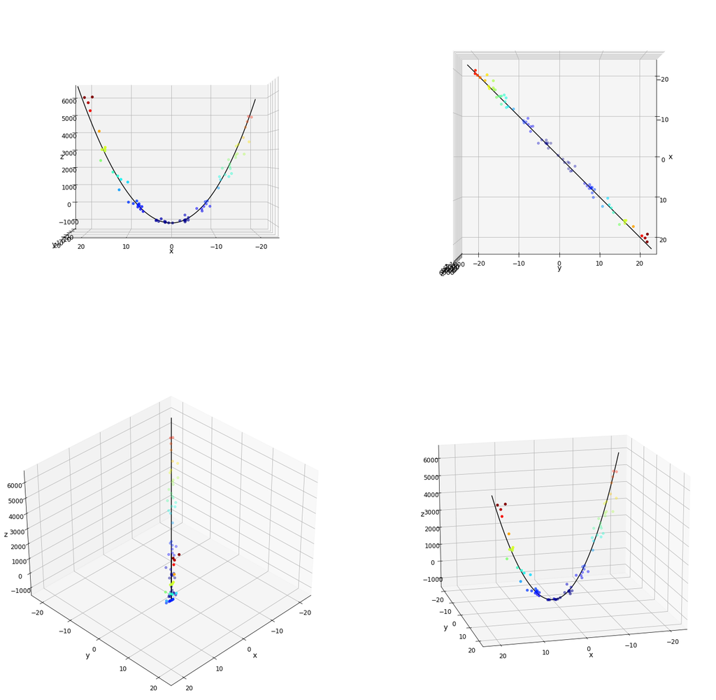

```python
#===================================================================================
# RECREATE FIRST IMAGE OF DATA AND PLOT REGRESSION LINE OF BEST FIT IN EACH SUBPLOTS
#===================================================================================

#DATA FOR 3D LINE
xline = x_fit
yline = y_fit
zline = z_fit

#RAW DATA
#GET SEPARATE 'x', 'y', AND 'z' DATA FROM PolynomialRegressionData_I DATASET
xdata = PolynomialRegressionData_I_Features["x"]
ydata = PolynomialRegressionData_I_Features["y"]
zdata = PolynomialRegressionData_I_Targets


fig = plt.figure(figsize = [25, 25])

#==============
# FIRST SUBPLOT
#==============
#IN THE 2 ROWS AND 2 COLUMNS PLOT HERE, THERE'S 1st SUBPLOT
ax1 = fig.add_subplot(2, 2, 1, projection = '3d')
#CHANGE DEFAULT VIEW ANGLE USING view_init() METHOD.
#ELEVATION: 0 DEGREES ABOVE x - y PLANE
#ROTATION: 90 DEGREES COUNTER CLOCKWISE ABOUT z-AXIS
ax1.view_init(0, 90)
#COLOR OF CMAP TO ZDATA
ax1.scatter3D(xdata, ydata, zdata, c=zdata, cmap='jet')
#3D LINE
ax1.plot3D(xline, yline, zline, 'black');

#===============
# SECOND SUBPLOT
#===============
#SET UP THE AXES FOR THE FIRST PLOT
ax2 = fig.add_subplot(2, 2, 2, projection = '3d')   #IN THE 2 ROWS AND 2 COLUMNS PLOT HERE, THERE'S 2nd SUBPLOT
#CHANGE DEFAULT VIEW ANGLE USING view_init() METHOD.
#ELEVATION: 90 DEGREES ABOVE x - y PLANE
#ROTATION: 0 DEGREES COUNTER CLOCKWISE ABOUT z-AXIS
ax2.view_init(90,0)
#COLOR OF CMAP TO ZDATA
ax2.scatter3D(xdata, ydata, zdata, c=zdata, cmap='jet')
#3D LINE
ax2.plot3D(xline, yline, zline, 'black');

#==============
# THIRD SUBPLOT
#==============
#IN THE 2 ROWS AND 2 COLUMNS PLOT HERE, THERE'S 3rd SUBPLOT
ax3 = fig.add_subplot(2, 2, 3, projection = '3d')
#CHANGE DEFAULT VIEW ANGLE USING view_init() METHOD.
#ELEVATION: 35 DEGREES ABOVE x - y PLANE
#ROTATION: 45 DEGREES COUNTER CLOCKWISE ABOUT z-AXIS
ax3.view_init(35, 45)
#COLOR OF CMAP TO ZDATA
ax3.scatter3D(xdata, ydata, zdata, c=zdata, cmap='jet')
#3D LINE
ax3.plot3D(xline, yline, zline, 'black');

#===============
# FOURTH SUBPLOT
#===============
#IN THE 2 ROWS AND 2 COLUMNS PLOT HERE, THERE'S 4th SUBPLOT
ax4 = fig.add_subplot(2, 2, 4, projection = '3d')
#CHANGE DEFAULT VIEW ANGLE USING view_init() METHOD.
#ELEVATION: 15 DEGREES ABOVE x - y PLANE
#ROTATION: 75 DEGREES COUNTER CLOCKWISE ABOUT z-AXIS
ax4.view_init(15,75)
#COLOR OF CMAP TO ZDATA
ax4.scatter3D(xdata, ydata, zdata, c=zdata, cmap='jet')
#3D LINE
ax4.plot3D(xline, yline, zline, 'black');


#================
# SET AXIS LABELS
#================
ax1.set_xlabel('x')
ax1.set_ylabel('y')
ax1.set_zlabel('z')

ax2.set_xlabel('x')
ax2.set_ylabel('y')
ax2.set_zlabel('z')

ax3.set_xlabel('x')
ax3.set_ylabel('y')
ax3.set_zlabel('z')

ax4.set_xlabel('x')
ax4.set_ylabel('y')
ax4.set_zlabel('z')


#==========
# SHOW PLOT
#==========
plt.show()
```

# INFERRING THE TRUE MODEL PARAMETERS

```python
print("True Model Coefficients: ", np.round(model.coef_).astype(int))
print("True Model Intercept : ", round(model.intercept_))
```

```
True Model Coefficients:  [ 8  0  0  0 16]
True Model Intercept :  -1000
```

```python
#Coefficient corresponding to dependent variable of the model:

list_of_coefficients = np.round(model.coef_).astype(int)

list_of_coefficient_variables = poly_features.get_feature_names()

print("Coefficients corresponding to dependent variables of the model:")
for i in range(len(list_of_coefficient_variables)):
    print(list_of_coefficient_variables[i], " = ", list_of_coefficients[i])
```

```
Coefficients corresponding to dependent variables of the model:
x0  =  8
x1  =  0
x0^2  =  0
x0 x1  =  0
x1^2  =  16
```